# Risk Factor Analysis

## Outcome Variable

**Outcome Variable:** swasted

## Predictor Variables

**Intervention Variable:** meducyrs

**Adjustment Set:**

unadjusted

## Stratifying Variables

The analysis was stratified on these variable(s):

- agecat
- studyid
- country

## Data Summary

| agecat | studyid | country | meducyrs | swasted | n_cell | n |
| --- | --- | --- | --- | --- | --- | --- |
| Birth | ki0047075b-MAL-ED | BANGLADESH | Low | 0 | 61 | 195 |
| Birth | ki0047075b-MAL-ED | BANGLADESH | Low | 1 | 2 | 195 |
| Birth | ki0047075b-MAL-ED | BANGLADESH | Medium | 0 | 57 | 195 |
| Birth | ki0047075b-MAL-ED | BANGLADESH | Medium | 1 | 3 | 195 |
| Birth | ki0047075b-MAL-ED | BANGLADESH | High | 0 | 71 | 195 |
| Birth | ki0047075b-MAL-ED | BANGLADESH | High | 1 | 1 | 195 |
| Birth | ki0047075b-MAL-ED | BRAZIL | Low | 0 | 51 | 182 |
| Birth | ki0047075b-MAL-ED | BRAZIL | Low | 1 | 0 | 182 |
| Birth | ki0047075b-MAL-ED | BRAZIL | Medium | 0 | 68 | 182 |
| Birth | ki0047075b-MAL-ED | BRAZIL | Medium | 1 | 0 | 182 |
| Birth | ki0047075b-MAL-ED | BRAZIL | High | 0 | 63 | 182 |
| Birth | ki0047075b-MAL-ED | BRAZIL | High | 1 | 0 | 182 |
| Birth | ki0047075b-MAL-ED | INDIA | Low | 0 | 59 | 180 |
| Birth | ki0047075b-MAL-ED | INDIA | Low | 1 | 1 | 180 |
| Birth | ki0047075b-MAL-ED | INDIA | Medium | 0 | 64 | 180 |
| Birth | ki0047075b-MAL-ED | INDIA | Medium | 1 | 5 | 180 |
| Birth | ki0047075b-MAL-ED | INDIA | High | 0 | 50 | 180 |
| Birth | ki0047075b-MAL-ED | INDIA | High | 1 | 1 | 180 |
| Birth | ki0047075b-MAL-ED | NEPAL | Low | 0 | 65 | 155 |
| Birth | ki0047075b-MAL-ED | NEPAL | Low | 1 | 0 | 155 |
| Birth | ki0047075b-MAL-ED | NEPAL | Medium | 0 | 51 | 155 |
| Birth | ki0047075b-MAL-ED | NEPAL | Medium | 1 | 2 | 155 |
| Birth | ki0047075b-MAL-ED | NEPAL | High | 0 | 36 | 155 |
| Birth | ki0047075b-MAL-ED | NEPAL | High | 1 | 1 | 155 |
| Birth | ki0047075b-MAL-ED | PERU | Low | 0 | 98 | 278 |
| Birth | ki0047075b-MAL-ED | PERU | Low | 1 | 0 | 278 |
| Birth | ki0047075b-MAL-ED | PERU | Medium | 0 | 98 | 278 |
| Birth | ki0047075b-MAL-ED | PERU | Medium | 1 | 0 | 278 |
| Birth | ki0047075b-MAL-ED | PERU | High | 0 | 82 | 278 |
| Birth | ki0047075b-MAL-ED | PERU | High | 1 | 0 | 278 |

[output cut: 378 more lines]

The following strata were considered:

- agecat: 24 months, studyid: ki0047075b-MAL-ED, country: BANGLADESH
- agecat: 24 months, studyid: ki0047075b-MAL-ED, country: BRAZIL
- agecat: 24 months, studyid: ki0047075b-MAL-ED, country: INDIA
- agecat: 24 months, studyid: ki0047075b-MAL-ED, country: NEPAL
- agecat: 24 months, studyid: ki0047075b-MAL-ED, country: PERU
- agecat: 24 months, studyid: ki0047075b-MAL-ED, country: SOUTH AFRICA
- agecat: 24 months, studyid: ki0047075b-MAL-ED, country: TANZANIA, UNITED REPUBLIC OF
- agecat: 24 months, studyid: ki1000108-CMC-V-BCS-2002, country: INDIA
- agecat: 24 months, studyid: ki1000108-IRC, country: INDIA
- agecat: 24 months, studyid: ki1017093-NIH-Birth, country: BANGLADESH
- agecat: 24 months, studyid: ki1017093b-PROVIDE, country: BANGLADESH
- agecat: 24 months, studyid: ki1017093c-NIH-Crypto, country: BANGLADESH
- agecat: 24 months, studyid: ki1066203-TanzaniaChild2, country: TANZANIA, UNITED REPUBLIC OF
- agecat: 24 months, studyid: ki1113344-GMS-Nepal, country: NEPAL
- agecat: 24 months, studyid: ki1119695-PROBIT, country: BELARUS
- agecat: 24 months, studyid: ki1126311-ZVITAMBO, country: ZIMBABWE
- agecat: 24 months, studyid: ki1135781-COHORTS, country: GUATEMALA
- agecat: 24 months, studyid: ki1135781-COHORTS, country: INDIA
- agecat: 24 months, studyid: ki1135781-COHORTS, country: PHILIPPINES
- agecat: 24 months, studyid: ki1148112-LCNI-5, country: MALAWI
- agecat: 24 months, studyid: kiGH5241-JiVitA-3, country: BANGLADESH
- agecat: 24 months, studyid: kiGH5241-JiVitA-4, country: BANGLADESH
- agecat: 6 months, studyid: ki0047075b-MAL-ED, country: BANGLADESH
- agecat: 6 months, studyid: ki0047075b-MAL-ED, country: BRAZIL
- agecat: 6 months, studyid: ki0047075b-MAL-ED, country: INDIA
- agecat: 6 months, studyid: ki0047075b-MAL-ED, country: NEPAL
- agecat: 6 months, studyid: ki0047075b-MAL-ED, country: PERU
- agecat: 6 months, studyid: ki0047075b-MAL-ED, country: SOUTH AFRICA
- agecat: 6 months, studyid: ki0047075b-MAL-ED, country: TANZANIA, UNITED REPUBLIC OF
- agecat: 6 months, studyid: ki1000108-CMC-V-BCS-2002, country: INDIA
- agecat: 6 months, studyid: ki1000108-IRC, country: INDIA
- agecat: 6 months, studyid: ki1000109-EE, country: PAKISTAN
- agecat: 6 months, studyid: ki1000304b-SAS-CompFeed, country: INDIA
- agecat: 6 months, studyid: ki1000304b-SAS-FoodSuppl, country: INDIA
- agecat: 6 months, studyid: ki1017093-NIH-Birth, country: BANGLADESH
- agecat: 6 months, studyid: ki1017093b-PROVIDE, country: BANGLADESH
- agecat: 6 months, studyid: ki1017093c-NIH-Crypto, country: BANGLADESH
- agecat: 6 months, studyid: ki1066203-TanzaniaChild2, country: TANZANIA, UNITED REPUBLIC OF
- agecat: 6 months, studyid: ki1112895-Guatemala BSC, country: GUATEMALA
- agecat: 6 months, studyid: ki1113344-GMS-Nepal, country: NEPAL
- agecat: 6 months, studyid: ki1119695-PROBIT, country: BELARUS
- agecat: 6 months, studyid: ki1126311-ZVITAMBO, country: ZIMBABWE
- agecat: 6 months, studyid: ki1135781-COHORTS, country: GUATEMALA
- agecat: 6 months, studyid: ki1135781-COHORTS, country: INDIA
- agecat: 6 months, studyid: ki1135781-COHORTS, country: PHILIPPINES
- agecat: 6 months, studyid: ki1148112-LCNI-5, country: MALAWI
- agecat: 6 months, studyid: kiGH5241-JiVitA-3, country: BANGLADESH
- agecat: 6 months, studyid: kiGH5241-JiVitA-4, country: BANGLADESH
- agecat: Birth, studyid: ki0047075b-MAL-ED, country: BANGLADESH
- agecat: Birth, studyid: ki0047075b-MAL-ED, country: BRAZIL
- agecat: Birth, studyid: ki0047075b-MAL-ED, country: INDIA
- agecat: Birth, studyid: ki0047075b-MAL-ED, country: NEPAL
- agecat: Birth, studyid: ki0047075b-MAL-ED, country: PERU
- agecat: Birth, studyid: ki0047075b-MAL-ED, country: SOUTH AFRICA
- agecat: Birth, studyid: ki0047075b-MAL-ED, country: TANZANIA, UNITED REPUBLIC OF
- agecat: Birth, studyid: ki1000108-CMC-V-BCS-2002, country: INDIA
- agecat: Birth, studyid: ki1000108-IRC, country: INDIA
- agecat: Birth, studyid: ki1000109-EE, country: PAKISTAN
- agecat: Birth, studyid: ki1000304b-SAS-CompFeed, country: INDIA
- agecat: Birth, studyid: ki1017093-NIH-Birth, country: BANGLADESH
- agecat: Birth, studyid: ki1017093c-NIH-Crypto, country: BANGLADESH
- agecat: Birth, studyid: ki1119695-PROBIT, country: BELARUS
- agecat: Birth, studyid: ki1126311-ZVITAMBO, country: ZIMBABWE
- agecat: Birth, studyid: ki1135781-COHORTS, country: GUATEMALA
- agecat: Birth, studyid: ki1135781-COHORTS, country: INDIA
- agecat: Birth, studyid: ki1135781-COHORTS, country: PHILIPPINES
- agecat: Birth, studyid: kiGH5241-JiVitA-3, country: BANGLADESH
- agecat: Birth, studyid: kiGH5241-JiVitA-4, country: BANGLADESH

### Dropped Strata

Some strata were dropped due to rare outcomes:

- agecat: Birth, studyid: ki0047075b-MAL-ED, country: BANGLADESH
- agecat: Birth, studyid: ki0047075b-MAL-ED, country: BRAZIL
- agecat: Birth, studyid: ki0047075b-MAL-ED, country: INDIA
- agecat: Birth, studyid: ki0047075b-MAL-ED, country: NEPAL
- agecat: Birth, studyid: ki0047075b-MAL-ED, country: PERU
- agecat: Birth, studyid: ki0047075b-MAL-ED, country: SOUTH AFRICA
- agecat: Birth, studyid: ki0047075b-MAL-ED, country: TANZANIA, UNITED REPUBLIC OF
- agecat: Birth, studyid: ki1000108-CMC-V-BCS-2002, country: INDIA
- agecat: Birth, studyid: ki1000109-EE, country: PAKISTAN
- agecat: Birth, studyid: ki1000304b-SAS-CompFeed, country: INDIA
- agecat: Birth, studyid: ki1017093-NIH-Birth, country: BANGLADESH
- agecat: Birth, studyid: ki1017093c-NIH-Crypto, country: BANGLADESH
- agecat: Birth, studyid: kiGH5241-JiVitA-4, country: BANGLADESH
- agecat: 6 months, studyid: ki0047075b-MAL-ED, country: BANGLADESH
- agecat: 6 months, studyid: ki0047075b-MAL-ED, country: BRAZIL
- agecat: 6 months, studyid: ki0047075b-MAL-ED, country: INDIA
- agecat: 6 months, studyid: ki0047075b-MAL-ED, country: NEPAL
- agecat: 6 months, studyid: ki0047075b-MAL-ED, country: PERU
- agecat: 6 months, studyid: ki0047075b-MAL-ED, country: SOUTH AFRICA
- agecat: 6 months, studyid: ki0047075b-MAL-ED, country: TANZANIA, UNITED REPUBLIC OF
- agecat: 6 months, studyid: ki1000108-CMC-V-BCS-2002, country: INDIA
- agecat: 6 months, studyid: ki1000109-EE, country: PAKISTAN
- agecat: 6 months, studyid: ki1000304b-SAS-CompFeed, country: INDIA
- agecat: 6 months, studyid: ki1000304b-SAS-FoodSuppl, country: INDIA
- agecat: 6 months, studyid: ki1017093-NIH-Birth, country: BANGLADESH
- agecat: 6 months, studyid: ki1017093b-PROVIDE, country: BANGLADESH
- agecat: 6 months, studyid: ki1017093c-NIH-Crypto, country: BANGLADESH
- agecat: 6 months, studyid: ki1066203-TanzaniaChild2, country: TANZANIA, UNITED REPUBLIC OF
- agecat: 6 months, studyid: ki1112895-Guatemala BSC, country: GUATEMALA
- agecat: 6 months, studyid: ki1113344-GMS-Nepal, country: NEPAL
- agecat: 6 months, studyid: ki1119695-PROBIT, country: BELARUS
- agecat: 6 months, studyid: ki1135781-COHORTS, country: GUATEMALA
- agecat: 6 months, studyid: ki1148112-LCNI-5, country: MALAWI
- agecat: 6 months, studyid: kiGH5241-JiVitA-4, country: BANGLADESH
- agecat: 24 months, studyid: ki0047075b-MAL-ED, country: BANGLADESH
- agecat: 24 months, studyid: ki0047075b-MAL-ED, country: BRAZIL
- agecat: 24 months, studyid: ki0047075b-MAL-ED, country: INDIA
- agecat: 24 months, studyid: ki0047075b-MAL-ED, country: NEPAL
- agecat: 24 months, studyid: ki0047075b-MAL-ED, country: PERU
- agecat: 24 months, studyid: ki0047075b-MAL-ED, country: SOUTH AFRICA
- agecat: 24 months, studyid: ki0047075b-MAL-ED, country: TANZANIA, UNITED REPUBLIC OF
- agecat: 24 months, studyid: ki1000108-CMC-V-BCS-2002, country: INDIA
- agecat: 24 months, studyid: ki1000108-IRC, country: INDIA
- agecat: 24 months, studyid: ki1017093-NIH-Birth, country: BANGLADESH
- agecat: 24 months, studyid: ki1017093b-PROVIDE, country: BANGLADESH
- agecat: 24 months, studyid: ki1017093c-NIH-Crypto, country: BANGLADESH
- agecat: 24 months, studyid: ki1066203-TanzaniaChild2, country: TANZANIA, UNITED REPUBLIC OF
- agecat: 24 months, studyid: ki1113344-GMS-Nepal, country: NEPAL
- agecat: 24 months, studyid: ki1119695-PROBIT, country: BELARUS
- agecat: 24 months, studyid: ki1135781-COHORTS, country: GUATEMALA
- agecat: 24 months, studyid: ki1135781-COHORTS, country: INDIA
- agecat: 24 months, studyid: ki1148112-LCNI-5, country: MALAWI
- agecat: 24 months, studyid: kiGH5241-JiVitA-4, country: BANGLADESH

## Methods Detail

We’re interested in the causal parameters $E[Y_a]$ for all values of $a \in \mathcal{A}$. These parameters represent the mean outcome if, possibly contrary to fact, we intervened to set all units to have $A=a$. Under the randomization and positivity assumptions, these are identified by the statistical parameters $\psi_a=E_W[E_{Y|A,W}(Y|A=a,W)]$. In addition, we’re interested in the mean of $Y$, $E[Y]$ under no intervention (the observed mean). We will estimate these parameters by using SuperLearner to fit the relevant likelihood factors – $E_{Y|A,W}(Y|A=a,W)$ and $p(A=a|W)$, and then updating our likelihood fit using a joint TMLE.

For unadjusted analyses ($W=\{\}$), initial likelihoods were estimated using Lrnr_glm to estimate the simple $E(Y|A)$ and Lrnr_mean to estimate $p(A)$. For adjusted analyses, a small library containing Lrnr_glmnet, Lrnr_xgboost, and Lrnr_mean was used.

Having estimated these parameters, we will then use the delta method to estimate relative risks and attributable risks relative to a prespecified baseline level of $A$.

# Results Detail

## Results Plots

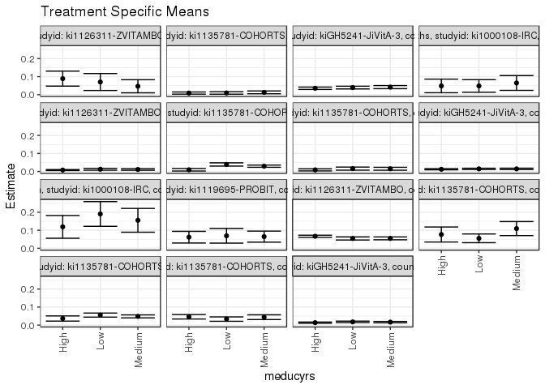

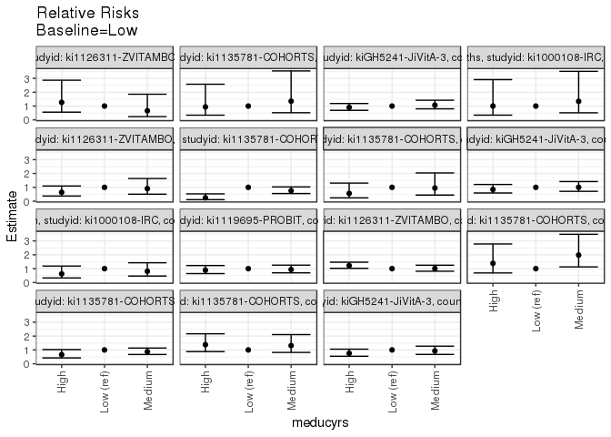

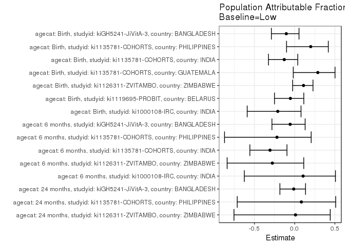

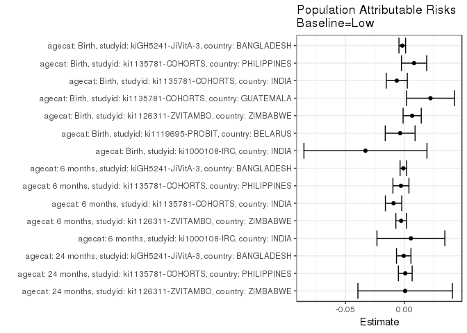

## Results Table

### Parameter: TSM

| agecat | studyid | country | intervention_level | baseline_level | estimate | ci_lower | ci_upper |
| --- | --- | --- | --- | --- | --- | --- | --- |
| Birth | ki1000108-IRC | INDIA | Low | NA | 0.1904762 | 0.1218117 | 0.2591406 |
| Birth | ki1000108-IRC | INDIA | Medium | NA | 0.1551724 | 0.0891875 | 0.2211573 |
| Birth | ki1000108-IRC | INDIA | High | NA | 0.1188119 | 0.0556165 | 0.1820073 |
| Birth | ki1119695-PROBIT | BELARUS | Low | NA | 0.0694051 | 0.0286305 | 0.1101797 |
| Birth | ki1119695-PROBIT | BELARUS | Medium | NA | 0.0647395 | 0.0340474 | 0.0954317 |
| Birth | ki1119695-PROBIT | BELARUS | High | NA | 0.0616071 | 0.0292362 | 0.0939781 |
| Birth | ki1126311-ZVITAMBO | ZIMBABWE | Low | NA | 0.0545252 | 0.0459543 | 0.0630962 |
| Birth | ki1126311-ZVITAMBO | ZIMBABWE | Medium | NA | 0.0549451 | 0.0470309 | 0.0628592 |
| Birth | ki1126311-ZVITAMBO | ZIMBABWE | High | NA | 0.0667142 | 0.0608748 | 0.0725536 |
| Birth | ki1135781-COHORTS | GUATEMALA | Low | NA | 0.0552326 | 0.0310769 | 0.0793882 |
| Birth | ki1135781-COHORTS | GUATEMALA | Medium | NA | 0.1093117 | 0.0703726 | 0.1482509 |
| Birth | ki1135781-COHORTS | GUATEMALA | High | NA | 0.0764331 | 0.0348455 | 0.1180207 |
| Birth | ki1135781-COHORTS | INDIA | Low | NA | 0.0555556 | 0.0443376 | 0.0667735 |
| Birth | ki1135781-COHORTS | INDIA | Medium | NA | 0.0484548 | 0.0402335 | 0.0566761 |
| Birth | ki1135781-COHORTS | INDIA | High | NA | 0.0365854 | 0.0222172 | 0.0509535 |
| Birth | ki1135781-COHORTS | PHILIPPINES | Low | NA | 0.0334129 | 0.0212432 | 0.0455825 |
| Birth | ki1135781-COHORTS | PHILIPPINES | Medium | NA | 0.0439443 | 0.0307897 | 0.0570988 |
| Birth | ki1135781-COHORTS | PHILIPPINES | High | NA | 0.0460993 | 0.0338597 | 0.0583389 |
| Birth | kiGH5241-JiVitA-3 | BANGLADESH | Low | NA | 0.0178830 | 0.0137119 | 0.0220542 |
| Birth | kiGH5241-JiVitA-3 | BANGLADESH | Medium | NA | 0.0165631 | 0.0127386 | 0.0203877 |
| Birth | kiGH5241-JiVitA-3 | BANGLADESH | High | NA | 0.0135542 | 0.0101029 | 0.0170055 |
| 6 months | ki1000108-IRC | INDIA | Low | NA | 0.0482759 | 0.0133443 | 0.0832074 |
| 6 months | ki1000108-IRC | INDIA | Medium | NA | 0.0647482 | 0.0237890 | 0.1057074 |
| 6 months | ki1000108-IRC | INDIA | High | NA | 0.0483871 | 0.0105720 | 0.0862022 |
| 6 months | ki1126311-ZVITAMBO | ZIMBABWE | Low | NA | 0.0122306 | 0.0070314 | 0.0174299 |
| 6 months | ki1126311-ZVITAMBO | ZIMBABWE | Medium | NA | 0.0111165 | 0.0065984 | 0.0156345 |
| 6 months | ki1126311-ZVITAMBO | ZIMBABWE | High | NA | 0.0078387 | 0.0052519 | 0.0104256 |
| 6 months | ki1135781-COHORTS | INDIA | Low | NA | 0.0388952 | 0.0298972 | 0.0478931 |
| 6 months | ki1135781-COHORTS | INDIA | Medium | NA | 0.0293508 | 0.0232029 | 0.0354988 |
| 6 months | ki1135781-COHORTS | INDIA | High | NA | 0.0094980 | 0.0024947 | 0.0165012 |
| 6 months | ki1135781-COHORTS | PHILIPPINES | Low | NA | 0.0157767 | 0.0072669 | 0.0242865 |
| 6 months | ki1135781-COHORTS | PHILIPPINES | Medium | NA | 0.0149942 | 0.0069033 | 0.0230852 |
| 6 months | ki1135781-COHORTS | PHILIPPINES | High | NA | 0.0088670 | 0.0030987 | 0.0146353 |
| 6 months | kiGH5241-JiVitA-3 | BANGLADESH | Low | NA | 0.0144449 | 0.0109924 | 0.0178975 |
| 6 months | kiGH5241-JiVitA-3 | BANGLADESH | Medium | NA | 0.0144997 | 0.0107334 | 0.0182660 |
| 6 months | kiGH5241-JiVitA-3 | BANGLADESH | High | NA | 0.0122127 | 0.0089681 | 0.0154573 |
| 24 months | ki1126311-ZVITAMBO | ZIMBABWE | Low | NA | 0.0701754 | 0.0232290 | 0.1171219 |
| 24 months | ki1126311-ZVITAMBO | ZIMBABWE | Medium | NA | 0.0465116 | 0.0101280 | 0.0828952 |
| 24 months | ki1126311-ZVITAMBO | ZIMBABWE | High | NA | 0.0888889 | 0.0472657 | 0.1305121 |
| 24 months | ki1135781-COHORTS | PHILIPPINES | Low | NA | 0.0093583 | 0.0024568 | 0.0162598 |
| 24 months | ki1135781-COHORTS | PHILIPPINES | Medium | NA | 0.0126582 | 0.0048609 | 0.0204555 |
| 24 months | ki1135781-COHORTS | PHILIPPINES | High | NA | 0.0087816 | 0.0027219 | 0.0148412 |
| 24 months | kiGH5241-JiVitA-3 | BANGLADESH | Low | NA | 0.0392452 | 0.0317247 | 0.0467656 |
| 24 months | kiGH5241-JiVitA-3 | BANGLADESH | Medium | NA | 0.0418457 | 0.0332295 | 0.0504619 |
| 24 months | kiGH5241-JiVitA-3 | BANGLADESH | High | NA | 0.0354866 | 0.0288216 | 0.0421517 |

### Parameter: E(Y)

| agecat | studyid | country | intervention_level | baseline_level | estimate | ci_lower | ci_upper |
| --- | --- | --- | --- | --- | --- | --- | --- |
| Birth | ki1000108-IRC | INDIA | NA | NA | 0.1574344 | 0.1188345 | 0.1960344 |
| Birth | ki1119695-PROBIT | BELARUS | NA | NA | 0.0658999 | 0.0328405 | 0.0989593 |
| Birth | ki1126311-ZVITAMBO | ZIMBABWE | NA | NA | 0.0612593 | 0.0571203 | 0.0653983 |
| Birth | ki1135781-COHORTS | GUATEMALA | NA | NA | 0.0775401 | 0.0583612 | 0.0967191 |
| Birth | ki1135781-COHORTS | INDIA | NA | NA | 0.0491904 | 0.0431214 | 0.0552594 |
| Birth | ki1135781-COHORTS | PHILIPPINES | NA | NA | 0.0417385 | 0.0344572 | 0.0490198 |
| Birth | kiGH5241-JiVitA-3 | BANGLADESH | NA | NA | 0.0161938 | 0.0138266 | 0.0185610 |
| 6 months | ki1000108-IRC | INDIA | NA | NA | 0.0539216 | 0.0319786 | 0.0758646 |
| 6 months | ki1126311-ZVITAMBO | ZIMBABWE | NA | NA | 0.0095746 | 0.0074733 | 0.0116759 |
| 6 months | ki1135781-COHORTS | INDIA | NA | NA | 0.0297762 | 0.0252454 | 0.0343071 |
| 6 months | ki1135781-COHORTS | PHILIPPINES | NA | NA | 0.0129342 | 0.0086762 | 0.0171922 |
| 6 months | kiGH5241-JiVitA-3 | BANGLADESH | NA | NA | 0.0136761 | 0.0115988 | 0.0157534 |
| 24 months | ki1126311-ZVITAMBO | ZIMBABWE | NA | NA | 0.0709220 | 0.0464309 | 0.0954131 |
| 24 months | ki1135781-COHORTS | PHILIPPINES | NA | NA | 0.0102082 | 0.0062264 | 0.0141901 |
| 24 months | kiGH5241-JiVitA-3 | BANGLADESH | NA | NA | 0.0387846 | 0.0344554 | 0.0431137 |

### Parameter: RR

| agecat | studyid | country | intervention_level | baseline_level | estimate | ci_lower | ci_upper |
| --- | --- | --- | --- | --- | --- | --- | --- |
| Birth | ki1000108-IRC | INDIA | Low | Low | 1.0000000 | 1.0000000 | 1.0000000 |
| Birth | ki1000108-IRC | INDIA | Medium | Low | 0.8146552 | 0.4665153 | 1.4225966 |
| Birth | ki1000108-IRC | INDIA | High | Low | 0.6237624 | 0.3280692 | 1.1859678 |
| Birth | ki1119695-PROBIT | BELARUS | Low | Low | 1.0000000 | 1.0000000 | 1.0000000 |
| Birth | ki1119695-PROBIT | BELARUS | Medium | Low | 0.9327778 | 0.6948062 | 1.2522548 |
| Birth | ki1119695-PROBIT | BELARUS | High | Low | 0.8876458 | 0.6435955 | 1.2242394 |
| Birth | ki1126311-ZVITAMBO | ZIMBABWE | Low | Low | 1.0000000 | 1.0000000 | 1.0000000 |
| Birth | ki1126311-ZVITAMBO | ZIMBABWE | Medium | Low | 1.0076998 | 0.8142123 | 1.2471671 |
| Birth | ki1126311-ZVITAMBO | ZIMBABWE | High | Low | 1.2235472 | 1.0220759 | 1.4647325 |
| Birth | ki1135781-COHORTS | GUATEMALA | Low | Low | 1.0000000 | 1.0000000 | 1.0000000 |
| Birth | ki1135781-COHORTS | GUATEMALA | Medium | Low | 1.9791178 | 1.1259091 | 3.4788842 |
| Birth | ki1135781-COHORTS | GUATEMALA | High | Low | 1.3838418 | 0.6885139 | 2.7813787 |
| Birth | ki1135781-COHORTS | INDIA | Low | Low | 1.0000000 | 1.0000000 | 1.0000000 |
| Birth | ki1135781-COHORTS | INDIA | Medium | Low | 0.8721862 | 0.6699875 | 1.1354075 |
| Birth | ki1135781-COHORTS | INDIA | High | Low | 0.6585366 | 0.4234440 | 1.0241505 |
| Birth | ki1135781-COHORTS | PHILIPPINES | Low | Low | 1.0000000 | 1.0000000 | 1.0000000 |
| Birth | ki1135781-COHORTS | PHILIPPINES | Medium | Low | 1.3151891 | 0.8208058 | 2.1073467 |
| Birth | ki1135781-COHORTS | PHILIPPINES | High | Low | 1.3796859 | 0.8790923 | 2.1653393 |
| Birth | kiGH5241-JiVitA-3 | BANGLADESH | Low | Low | 1.0000000 | 1.0000000 | 1.0000000 |
| Birth | kiGH5241-JiVitA-3 | BANGLADESH | Medium | Low | 0.9261933 | 0.6740978 | 1.2725661 |
| Birth | kiGH5241-JiVitA-3 | BANGLADESH | High | Low | 0.7579372 | 0.5435161 | 1.0569489 |
| 6 months | ki1000108-IRC | INDIA | Low | Low | 1.0000000 | 1.0000000 | 1.0000000 |
| 6 months | ki1000108-IRC | INDIA | Medium | Low | 1.3412127 | 0.5129682 | 3.5067510 |
| 6 months | ki1000108-IRC | INDIA | High | Low | 1.0023041 | 0.3455050 | 2.9076674 |
| 6 months | ki1126311-ZVITAMBO | ZIMBABWE | Low | Low | 1.0000000 | 1.0000000 | 1.0000000 |
| 6 months | ki1126311-ZVITAMBO | ZIMBABWE | Medium | Low | 0.9089047 | 0.5047747 | 1.6365869 |
| 6 months | ki1126311-ZVITAMBO | ZIMBABWE | High | Low | 0.6409108 | 0.3741762 | 1.0977894 |
| 6 months | ki1135781-COHORTS | INDIA | Low | Low | 1.0000000 | 1.0000000 | 1.0000000 |
| 6 months | ki1135781-COHORTS | INDIA | Medium | Low | 0.7546141 | 0.5523201 | 1.0310006 |
| 6 months | ki1135781-COHORTS | INDIA | High | Low | 0.2441940 | 0.1127514 | 0.5288692 |
| 6 months | ki1135781-COHORTS | PHILIPPINES | Low | Low | 1.0000000 | 1.0000000 | 1.0000000 |
| 6 months | ki1135781-COHORTS | PHILIPPINES | Medium | Low | 0.9504037 | 0.4431559 | 2.0382607 |
| 6 months | ki1135781-COHORTS | PHILIPPINES | High | Low | 0.5620311 | 0.2414077 | 1.3084871 |
| 6 months | kiGH5241-JiVitA-3 | BANGLADESH | Low | Low | 1.0000000 | 1.0000000 | 1.0000000 |
| 6 months | kiGH5241-JiVitA-3 | BANGLADESH | Medium | Low | 1.0037886 | 0.7113819 | 1.4163864 |
| 6 months | kiGH5241-JiVitA-3 | BANGLADESH | High | Low | 0.8454659 | 0.5916646 | 1.2081383 |
| 24 months | ki1126311-ZVITAMBO | ZIMBABWE | Low | Low | 1.0000000 | 1.0000000 | 1.0000000 |
| 24 months | ki1126311-ZVITAMBO | ZIMBABWE | Medium | Low | 0.6627907 | 0.2367871 | 1.8552176 |
| 24 months | ki1126311-ZVITAMBO | ZIMBABWE | High | Low | 1.2666667 | 0.5597884 | 2.8661625 |
| 24 months | ki1135781-COHORTS | PHILIPPINES | Low | Low | 1.0000000 | 1.0000000 | 1.0000000 |
| 24 months | ki1135781-COHORTS | PHILIPPINES | Medium | Low | 1.3526221 | 0.5174500 | 3.5357743 |
| 24 months | ki1135781-COHORTS | PHILIPPINES | High | Low | 0.9383723 | 0.3417855 | 2.5763019 |
| 24 months | kiGH5241-JiVitA-3 | BANGLADESH | Low | Low | 1.0000000 | 1.0000000 | 1.0000000 |
| 24 months | kiGH5241-JiVitA-3 | BANGLADESH | Medium | Low | 1.0662639 | 0.8002439 | 1.4207152 |
| 24 months | kiGH5241-JiVitA-3 | BANGLADESH | High | Low | 0.9042300 | 0.6905993 | 1.1839456 |

### Parameter: PAR

| agecat | studyid | country | intervention_level | baseline_level | estimate | ci_lower | ci_upper |
| --- | --- | --- | --- | --- | --- | --- | --- |
| Birth | ki1000108-IRC | INDIA | Low | NA | -0.0330418 | -0.0853947 | 0.0193111 |
| Birth | ki1119695-PROBIT | BELARUS | Low | NA | -0.0035052 | -0.0162040 | 0.0091936 |
| Birth | ki1126311-ZVITAMBO | ZIMBABWE | Low | NA | 0.0067341 | -0.0010040 | 0.0144721 |
| Birth | ki1135781-COHORTS | GUATEMALA | Low | NA | 0.0223075 | 0.0019449 | 0.0426702 |
| Birth | ki1135781-COHORTS | INDIA | Low | NA | -0.0063651 | -0.0153114 | 0.0025811 |
| Birth | ki1135781-COHORTS | PHILIPPINES | Low | NA | 0.0083256 | -0.0024213 | 0.0190726 |
| Birth | kiGH5241-JiVitA-3 | BANGLADESH | Low | NA | -0.0016892 | -0.0045187 | 0.0011403 |
| 6 months | ki1000108-IRC | INDIA | Low | NA | 0.0056457 | -0.0232403 | 0.0345317 |
| 6 months | ki1126311-ZVITAMBO | ZIMBABWE | Low | NA | -0.0026560 | -0.0071502 | 0.0018381 |
| 6 months | ki1135781-COHORTS | INDIA | Low | NA | -0.0091189 | -0.0160734 | -0.0021644 |
| 6 months | ki1135781-COHORTS | PHILIPPINES | Low | NA | -0.0028425 | -0.0096575 | 0.0039725 |
| 6 months | kiGH5241-JiVitA-3 | BANGLADESH | Low | NA | -0.0007688 | -0.0035691 | 0.0020315 |
| 24 months | ki1126311-ZVITAMBO | ZIMBABWE | Low | NA | 0.0007465 | -0.0394508 | 0.0409439 |
| 24 months | ki1135781-COHORTS | PHILIPPINES | Low | NA | 0.0008500 | -0.0050144 | 0.0067143 |
| 24 months | kiGH5241-JiVitA-3 | BANGLADESH | Low | NA | -0.0004606 | -0.0066065 | 0.0056853 |

### Parameter: PAF

| agecat | studyid | country | intervention_level | baseline_level | estimate | ci_lower | ci_upper |
| --- | --- | --- | --- | --- | --- | --- | --- |
| Birth | ki1000108-IRC | INDIA | Low | NA | -0.2098765 | -0.5897267 | 0.0792120 |
| Birth | ki1119695-PROBIT | BELARUS | Low | NA | -0.0531900 | -0.2509425 | 0.1133012 |
| Birth | ki1126311-ZVITAMBO | ZIMBABWE | Low | NA | 0.1099275 | -0.0255689 | 0.2275223 |
| Birth | ki1135781-COHORTS | GUATEMALA | Low | NA | 0.2876905 | -0.0174661 | 0.5013250 |
| Birth | ki1135781-COHORTS | INDIA | Low | NA | -0.1293981 | -0.3260016 | 0.0380553 |
| Birth | ki1135781-COHORTS | PHILIPPINES | Low | NA | 0.1994714 | -0.1012140 | 0.4180550 |
| Birth | kiGH5241-JiVitA-3 | BANGLADESH | Low | NA | -0.1043126 | -0.2893124 | 0.0541420 |
| 6 months | ki1000108-IRC | INDIA | Low | NA | 0.1047022 | -0.6258835 | 0.5070015 |
| 6 months | ki1126311-ZVITAMBO | ZIMBABWE | Low | NA | -0.2774047 | -0.8390556 | 0.1127170 |
| 6 months | ki1135781-COHORTS | INDIA | Low | NA | -0.3062490 | -0.5568378 | -0.0959950 |
| 6 months | ki1135781-COHORTS | PHILIPPINES | Low | NA | -0.2197642 | -0.8713588 | 0.2049495 |
| 6 months | kiGH5241-JiVitA-3 | BANGLADESH | Low | NA | -0.0562153 | -0.2825910 | 0.1302054 |
| 24 months | ki1126311-ZVITAMBO | ZIMBABWE | Low | NA | 0.0105263 | -0.7545639 | 0.4419934 |
| 24 months | ki1135781-COHORTS | PHILIPPINES | Low | NA | 0.0832620 | -0.7138263 | 0.5096303 |
| 24 months | kiGH5241-JiVitA-3 | BANGLADESH | Low | NA | -0.0118759 | -0.1834263 | 0.1348065 |